# Multivariate Analysis Lecture 02: Matrix Operations

Zhaoxia Yu

Professor, Department of Statistics

2026-05-31

# Multiplication

## Matrix Multiplication

### Definition of Matrix Multiplication

- Consider matrix $A_{m\times n}$ and matrix $B_{n\times p}$.
- How does $AB$ look like?
- $AB$ has $m$ rows and $p$ columns
- What is the value in the $i$th row and $j$th column of $AB$? We often denote it as the $(i,j)$th element/entry of $AB$:
  $$\left(AB\right)_{i,j}=\sum_{k=1}^n a_{ik}b_{kj}$$

### Definition of Matrix Multiplication

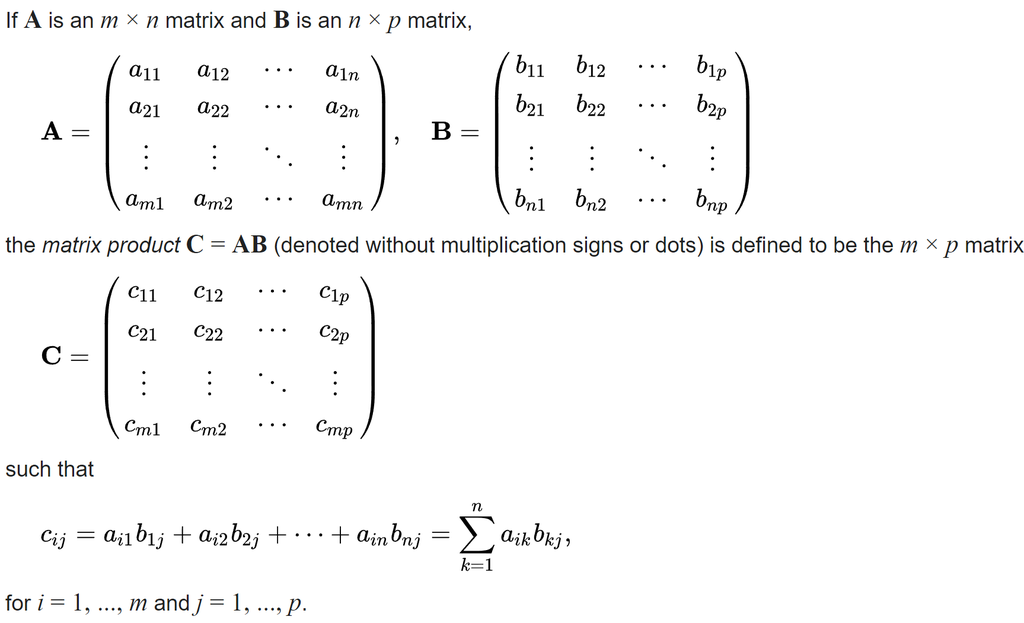

### Matrix Multiplication

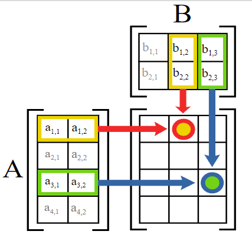

### Conformable Matrices

# Iris

## The Iris Data

### Iris data

- Three species of iris flowers: setosa, versicolor, and virginica
- Four features: sepal length, sepal width, petal length, and petal width

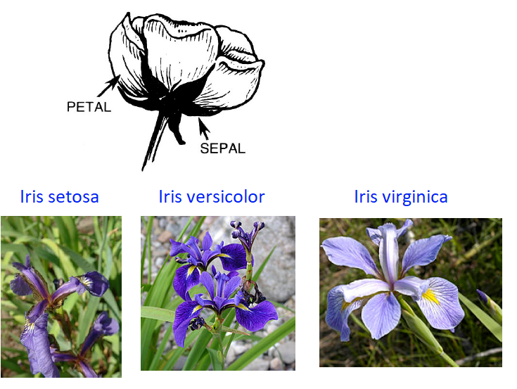

### Introduction

- The iris dataset is a widely used dataset to illustrate various methods, algorithms, and problems.
- Iris dataset serves as an excellent example of how data can be used to gain insights into different fields.
- It is available in many places
  - It is available from UCI Machine Learning Repository.
  - It is also included as a built-in data set in R. Use “data()” to see the list of built-in data sets.
  - Wikipedia has a page for the dataset.
- Its simplicity and easy availability have made it a widely used dataset for educational and research purposes.

### History

- The iris dataset has a rich history and has been used in many different areas of research
- It was first introduced by Ronald Fisher in 1936.
- The dataset contains measurements of four features of three species of iris flowers.
- Fisher used the iris dataset as an example of discriminant analysis

### Iris data

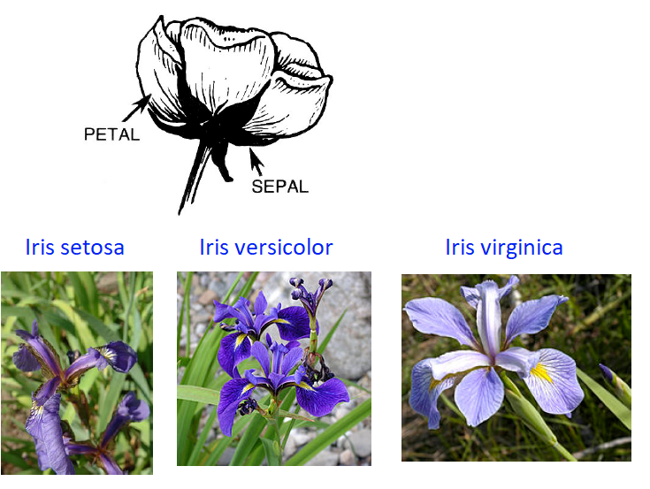

### Iris data in R

- The iris data is stored in two different formats:
  - as a 3D array: iris3
  - as a long matrix: iris

```r
#?iris
dim(iris3)
```

```
[1] 50  4  3
```

```r
dim(iris)
```

```
[1] 150   5
```

### Iris data in R

```r
dimnames(iris3)
```

```
[[1]]
NULL

[[2]]
[1] "Sepal L." "Sepal W." "Petal L." "Petal W."

[[3]]
[1] "Setosa"     "Versicolor" "Virginica"
```

```r
names(iris)
```

```
[1] "Sepal.Length" "Sepal.Width"  "Petal.Length" "Petal.Width"  "Species"
```

### Iris data in R

```r
#the attributes is a useful function to understand data
attributes(iris3)
```

```
$dim
[1] 50  4  3

$dimnames
$dimnames[[1]]
NULL

$dimnames[[2]]
[1] "Sepal L." "Sepal W." "Petal L." "Petal W."

$dimnames[[3]]
[1] "Setosa"     "Versicolor" "Virginica"
```

### Iris data in R

```r
#the attributes is a useful function to understand data
attributes(iris)
```

```
$names
[1] "Sepal.Length" "Sepal.Width"  "Petal.Length" "Petal.Width"  "Species"

$class
[1] "data.frame"

$row.names
  [1]   1   2   3   4   5   6   7   8   9  10  11  12  13  14  15  16  17  18
 [19]  19  20  21  22  23  24  25  26  27  28  29  30  31  32  33  34  35  36
 [37]  37  38  39  40  41  42  43  44  45  46  47  48  49  50  51  52  53  54
 [55]  55  56  57  58  59  60  61  62  63  64  65  66  67  68  69  70  71  72
 [73]  73  74  75  76  77  78  79  80  81  82  83  84  85  86  87  88  89  90
 [91]  91  92  93  94  95  96  97  98  99 100 101 102 103 104 105 106 107 108
[109] 109 110 111 112 113 114 115 116 117 118 119 120 121 122 123 124 125 126
[127] 127 128 129 130 131 132 133 134 135 136 137 138 139 140 141 142 143 144
[145] 145 146 147 148 149 150
```

### Heatmap of the Iris Data

```r
Y=as.matrix(iris[, 1:4])
rownames(Y)=iris[,5]
colnames(Y)=c("SepL", "SepW", "PetL", "PetW")
heatmap(Y[150:1, ],col=rainbow(12),Rowv=NA, Colv=NA)
```

### Heatmap of the Iris Data

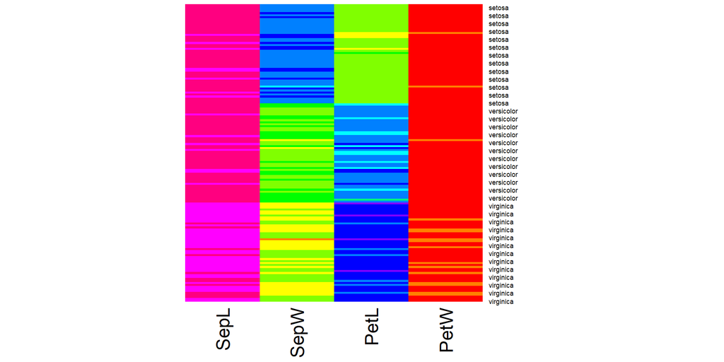